# Stratification and Prioritization of Denmark

27/10, 2021

## Stratification of Denmark

## Separate into classes

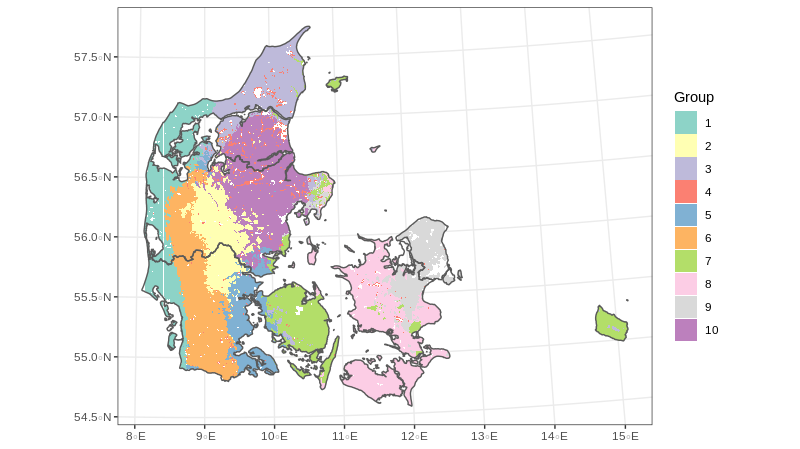

## How to decide on number of classes

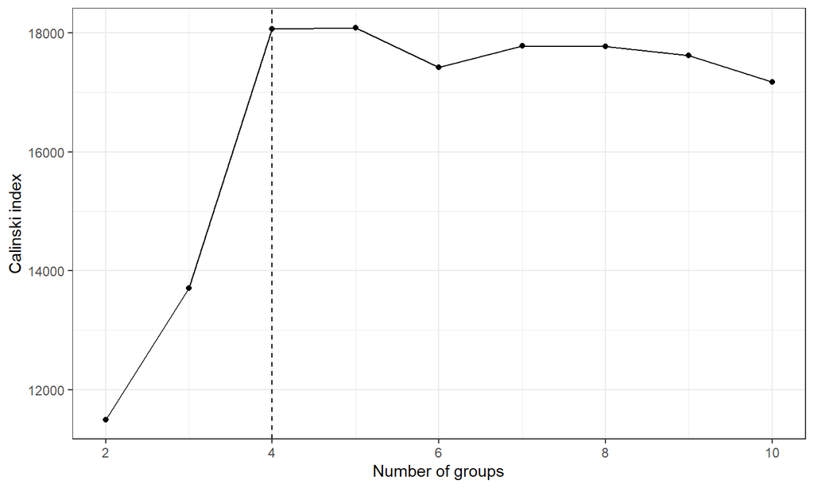

## Drivers of climate change

- Climate change
- Habitat degradation
- **Explotation**
- **Pollution (Nitrogen, Phosphorus, Air pollution)**
- Invasive species

## Climate change

## Climate change

- Four different future scenarios
- Climate change velocity
- Extreme conditions

## Compared to current conditions

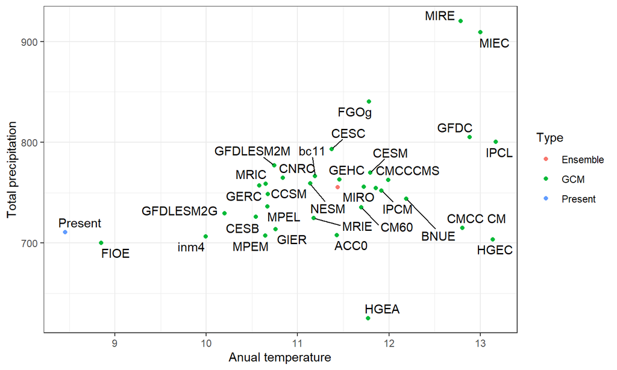

## Comparison among futures

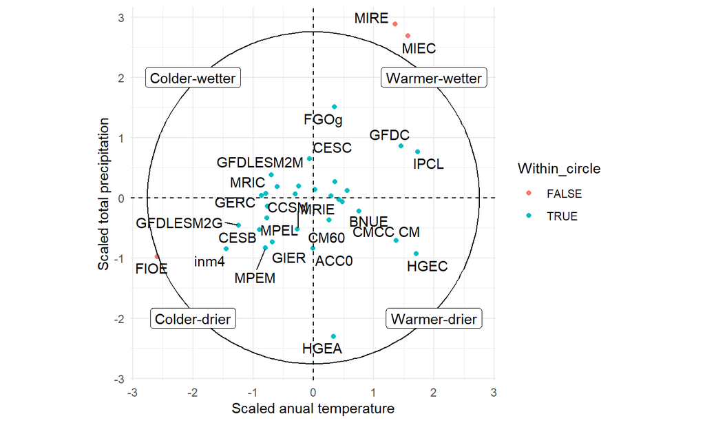

## Selected GCMs

- Based of four corners (Fajardo *et al.*, 2020)

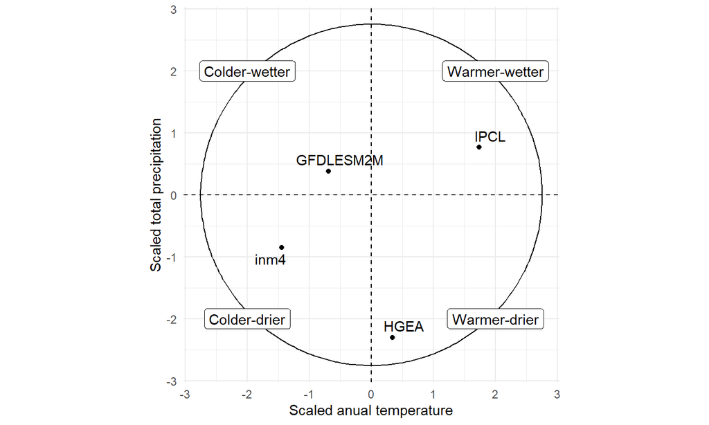

- We are working on higher resolution climate for Denmark

## Example of climate change Velocity

- Kms per year

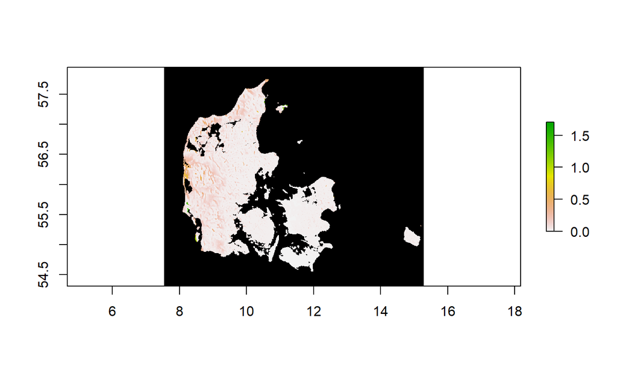

## Biodiversity and invasive species

## Data for Denmark

- From BIEN, we looked for all the presences of species present in Denmark
  - Native: 987
  - Introduced: 208 (more introduced species have also been modeled)
- Model current and 4 future scenarios

## Invasive Species

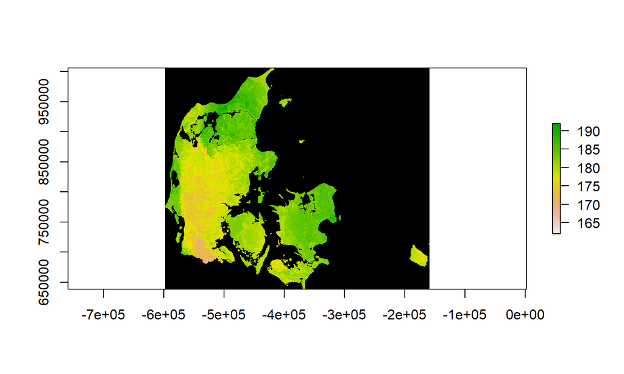

## Native species current richness

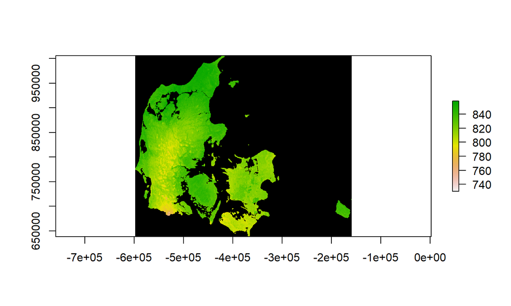

## Rarity

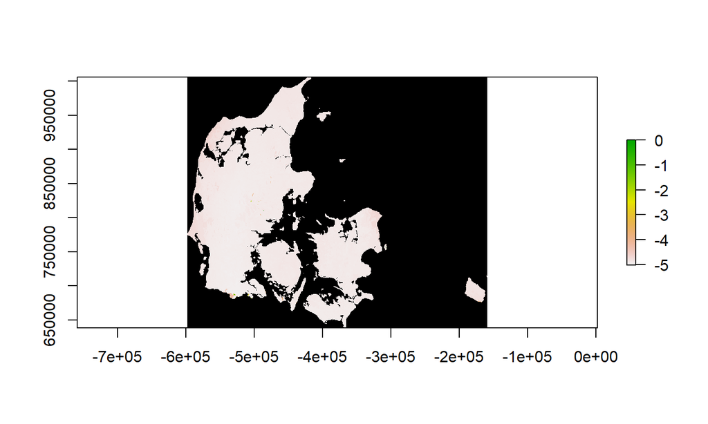

## Concensus (Example)

- When current and future ranges are aligned

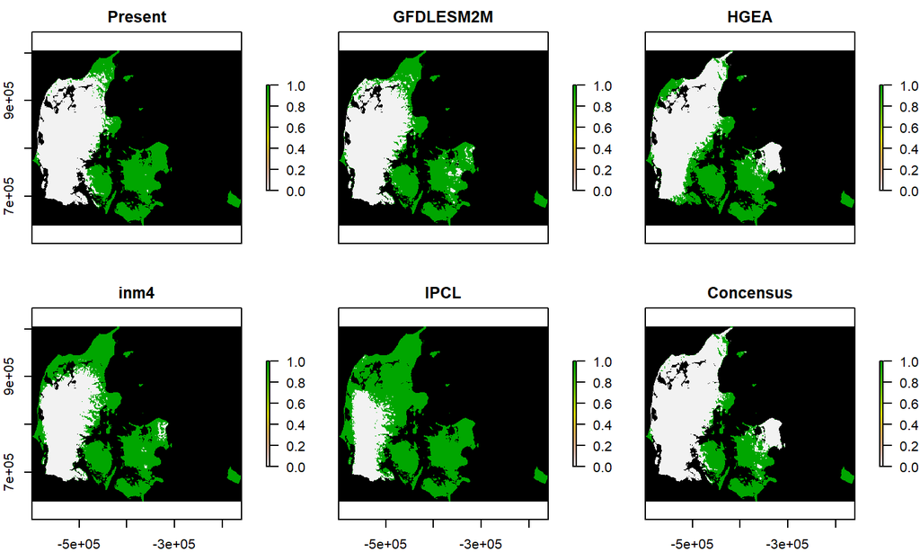

## Concensus richness

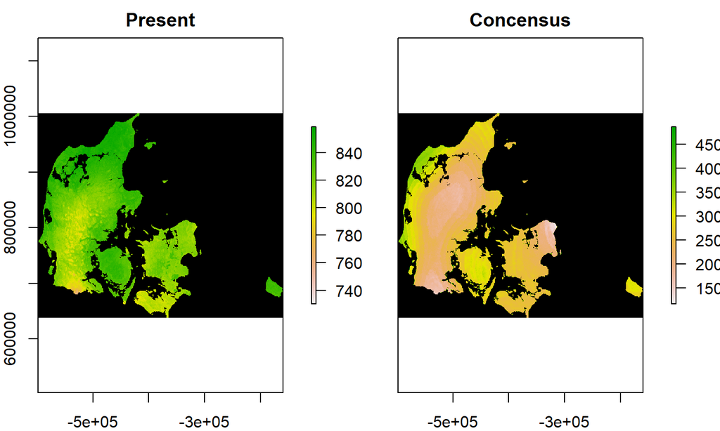

- Present richness vs concensus richness
- Better options with migrations, artscore, and other metrics
- Other taxa

## Habitat degradation

## Agriculture

- Naidoo and Iwamura (2007)
- Based on potential crop and livestock production
- Does not consider climate change (We can do better)

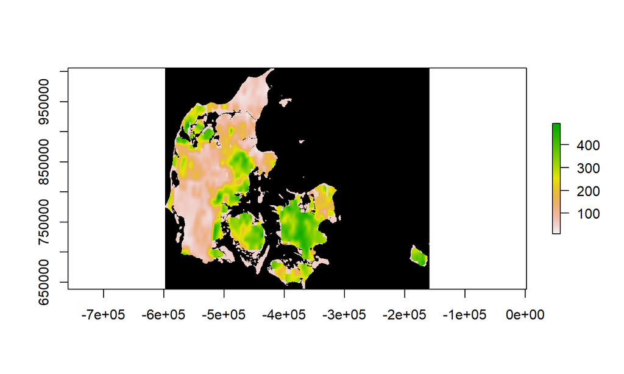

## Human footprint

- Copenhagen shows how different they are

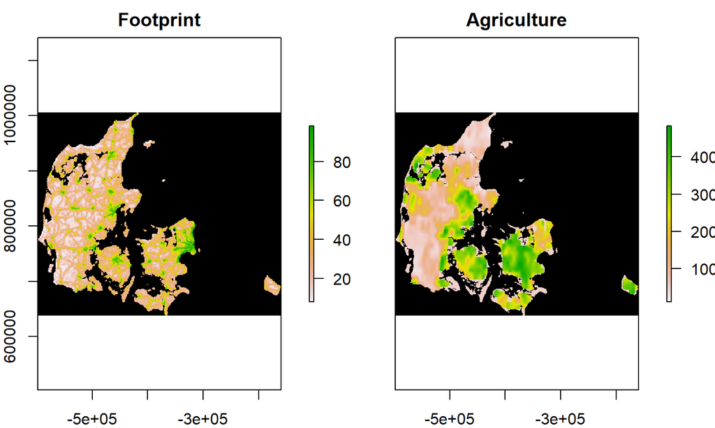

## Prioritization

## Minimum Cost

\[{\mathit{Minimize} \space \sum_{i = 1}^{I} x_i c_i \\}\]

- Every \(i\) is a cell, where \(c_i\) is the cost for each cell.
- \(x_i\) is a decision of 0 not to use in prioritization and 1 to use in a prioritization

## Naive prioritization

- Only take into account species (10% coverage)

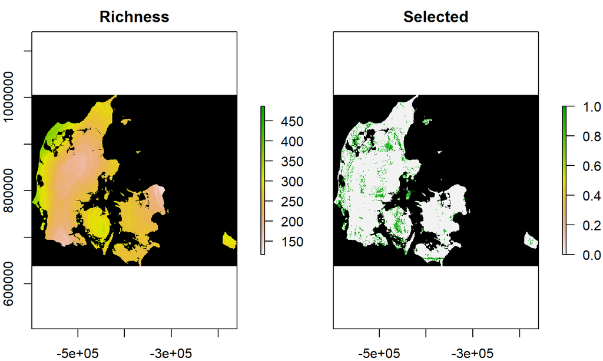

## Add Agriculture

- Add Agriculture as cost (min cost)

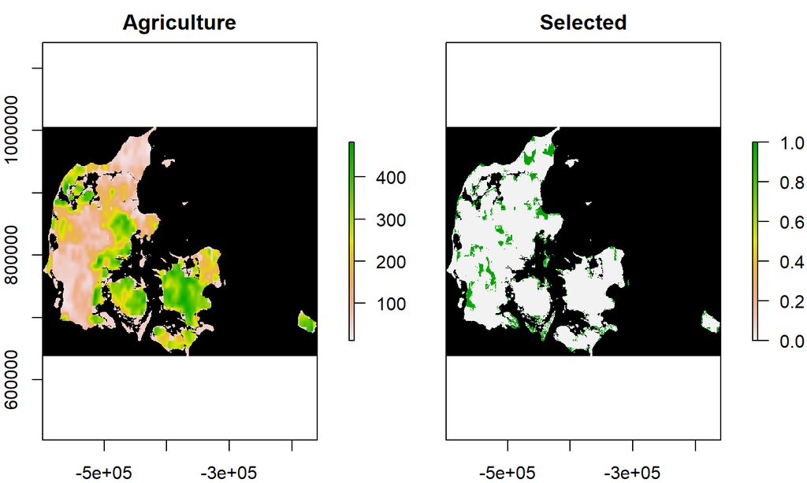

## We dont start from scratch

- Start with protected areas, eliminate cities (HFP)

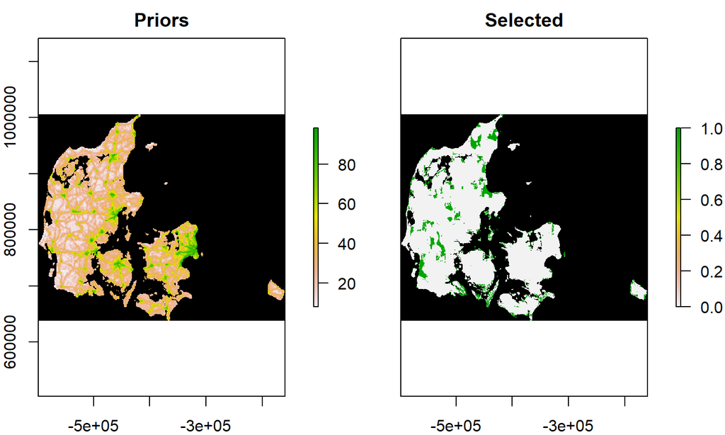

## Maximum utility

\[{\mathit{Maximize} \space \sum_{i = 1}^{I} -s \space c_i \space x_i + \sum_{j = 1}^{J} a_j w_j \\}\]

- where \(c_i\) is the cost of cell \(i\)
- \(x_i\) is the decision to use (1) or not use (0) cell i in the final solution
- \(a_j\) is the amount of feature \(j\) in cell \(i\) and \(w_j\) is the weight of each feature
- \(s\) is a scaling factor used to shrink the costs so that the problem will return a cheapest solution

Subject to

\[\sum_{i = 1}^{I} x_i c_i \leq B\]

- Where B is a budget (don’t need to set fixed boudaries)

## Using weights and different budgets

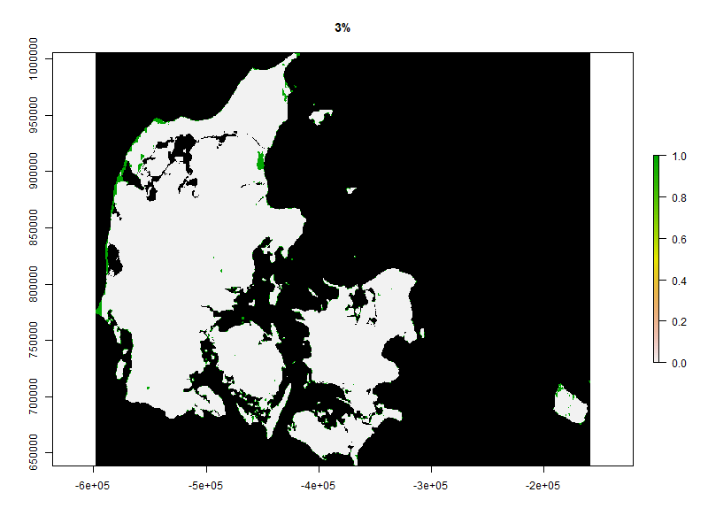

## closest to 10 and 30%

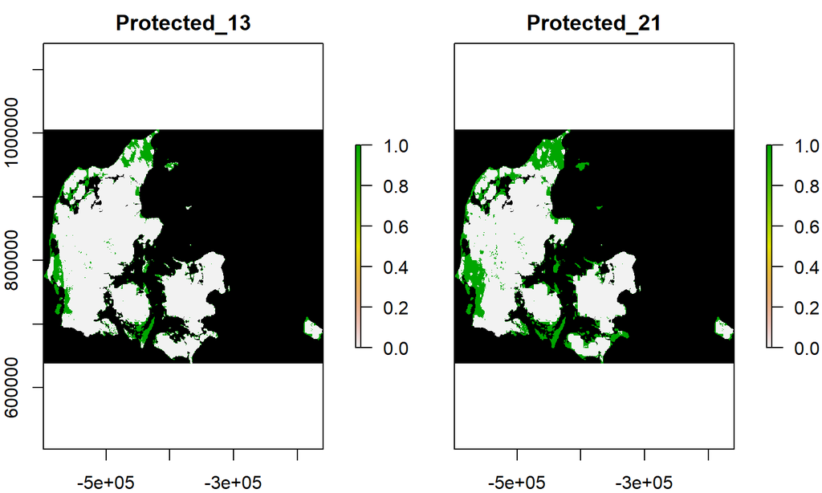

## Desicions to make

## Objective function

- We should probably test different objective functions
  - Minimum cost
  - Maximum utility
  - Minimum largest shortfall

## Features

- Ecosystem services
- Microbiota diversity and anssambles

## Constrains

- Carbon stock
- Pesticide reduction
- Food needs (i.e. 55,000 Tons of livestock)

## Need to build some projections

- Agriculture and land use Best guess for the future
  - Projected yieald with climate change
  - Ideas on how to manage land use and check (could use ideal vs projected scenarios)
  - More local projections
- Carbons stock, acumulated per cell per time-slice